# Single Read Sampling

# 2 Single-read sampling data for each population.year

## 2.1 SFS & expected heterozygostiy (He)

```r
#### Calculate SFS from IBS data
ifiles<-list.files('../Data/IBS/', pattern='.ibs.gz')
mfiles<-list.files('../Data/IBS/', pattern='.mafs.gz')

summaryHe<-data.frame(V=1:length(ifiles))
for (f in 1: length(ifiles)){
    ibs <- fread(paste0('../Data/IBS/', ifiles[f]))
    mf<-fread(paste0('../Data/IBS/', mfiles[f]))
    samplename<-gsub(".ibs.gz", '', ifiles[f])

    #rename the column
    names(ibs)[1:(ncol(ibs)-1)]<-names(ibs)[2:ncol(ibs)]
    ibs<-ibs[,1:(ncol(ibs)-1)]
    names(ibs)[1:2]<-c("chromo","position")
    #number of sample
    n<-ncol(ibs)-4

    #Attach the total samples for the loci
    ibs$nInd<-mf$nInd

    #remove the sites with less than n/2 samples
    ibs<-ibs[ibs$nInd >=n/2,]
    freq<-ibs[,1:4]
    freq$count<-apply(ibs[,5:(n+4)], 1, function(x) {
            x=x[x!=-1]
            x=x[!is.na(x)]
            a=length(x[x==1])
            return(a)})
    freq$nInd<-ibs$nInd
    freq$maf<-freq$count/freq$nInd
    freq<-merge(freq, mf[,c("chromo","position","knownEM")])

    #sfs
    sfs<-data.frame(table(freq$count))
    samplename<-gsub(".ibs.gz", '', ifiles[f])
    write.csv(sfs, paste0("../Output/SingleRead/SFS_",samplename,".csv"))

    #Create a plot
    #remove invariant sites
    sfs<-sfs[sfs$Var1!=0,]
    sfs<-sfs[sfs$Var1!=n,]

    ggplot(data=sfs, aes(x=Var1, y=Freq))+
        geom_bar(stat="identity", color="gray")+xlab("Frequency")+ ylab("Number of SNPs")+
        theme_classic()+
        scale_y_continuous(labels=scales::comma)+scale_x_discrete(breaks=seq(0,n, 10))+
        ggtitle(samplename)
    ggsave(paste0("../Output/SingleRead/SFS_",samplename,".png"), width = 5,height = 3.6, dpi=300)

    #calculate He
    freq$het1<-freq$knownEM*2*(1-freq$knownEM)
    freq$het2<-freq$maf*2*(1-freq$maf)
    write.csv(freq, file=gzfile(paste0("../Output/SingleRead/Het_", samplename,".csv.gz")))

    summaryHe$pop[f]<-samplename
    summaryHe$He_knownEM[f]<-mean(freq$het1)
    summaryHe$He_maf[f]<-mean(freq$het2, na.rm=T)
    print(f)
}

write.csv(summaryHe[,2:4], "../Output/SingleRead/Het_mean_compare.csv")

summaryHe<-summaryHe2
summaryHe$pop<-factor(summaryHe$pop, levels=c("TB91","TB96","TB06","TB17","PWS91","PWS96","PWS07","PWS17","CA17"))

summ<-melt(summaryHe[,2:4], id.vars="pop")
summ$He<-as.numeric(summ$He)
colnames(summ)[2:3]<-c("Method","He")
ggplot(summ, aes(x=pop, y=He, color=Method))+
    geom_point(size=2)+ylim(0.1,0.22)+theme_classic()+ylab("Mean He")+xlab('')+
    theme(legend.title = element_blank())
ggsave("../Output/SingleRead/Estimated_He.png", width = 6, height = 4, dpi=300)
```

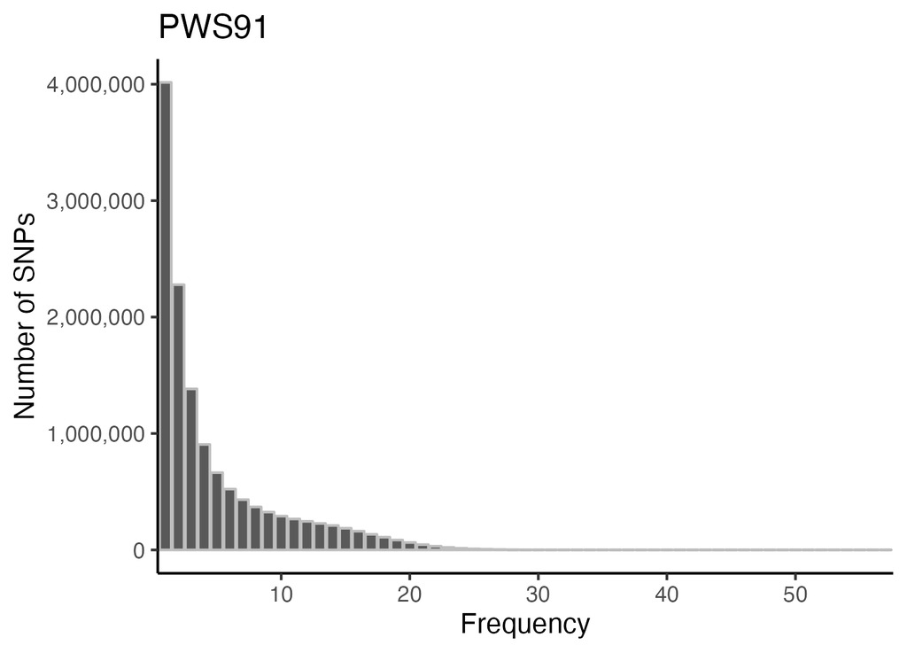

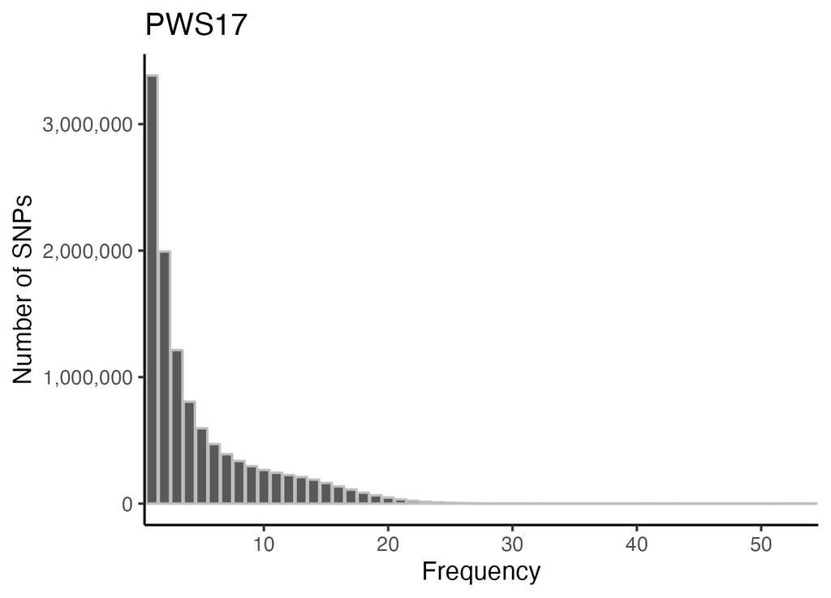

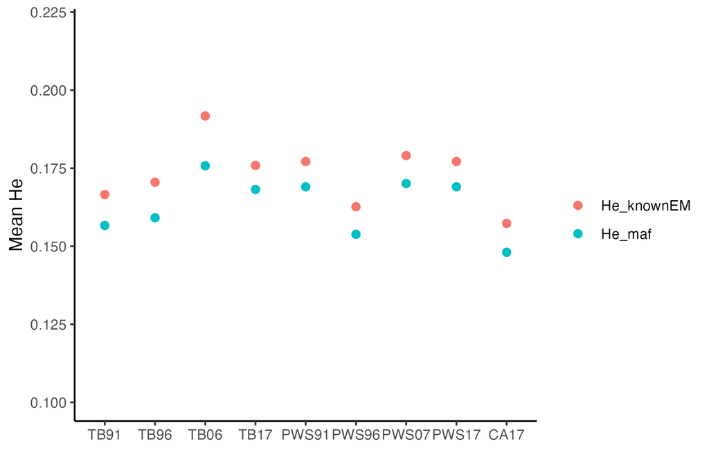

* Compare to read coverage

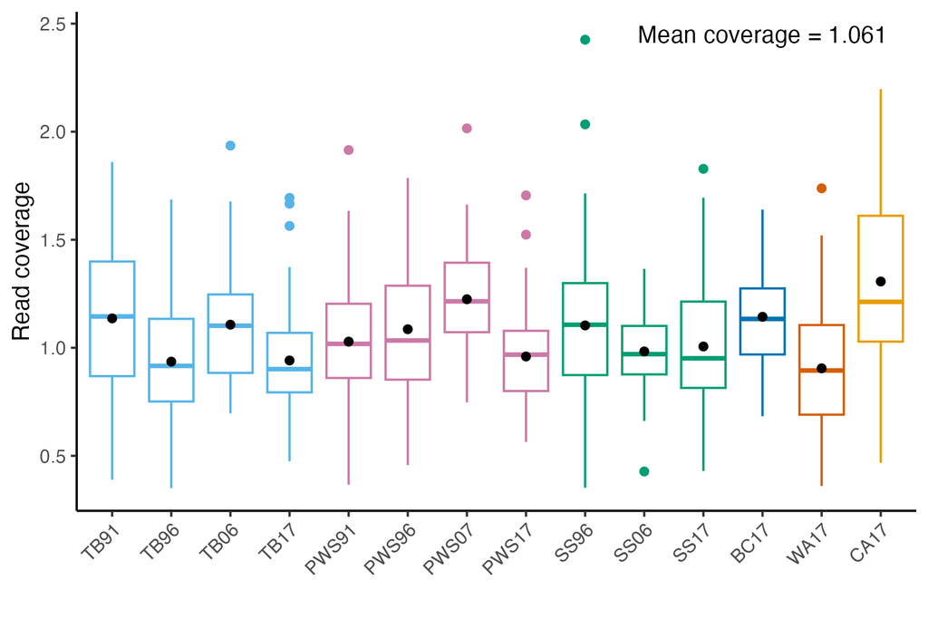

- Not correlated anymore!

## 2.2 Plot all SFS together

```r
pops_info<-read.csv("../Data/Sample_metadata_892pops.csv")
pops<-unique(pops_info$Population.Year)
popn<-data.frame(table(pops_info$Population.Year))


sfiles<-list.files("../Output/SingleRead/", pattern = "SFS_.+.csv")
SFS<-data.frame()
for(i in 1:length(sfiles)){
    df<-read.csv(paste0("../Output/SingleRead/", sfiles[i]), row.names = 1)

    popname<-gsub("SFS_",'',sfiles[i])
    popname<-gsub(".csv","",popname)
    #sample size per pop
    samplen<-popn$Freq[popn$Var1==popname]
    #remove invariant sites
    df<-df[!(df$Var1 %in% c(0, samplen)),]

    df$pop<-popname
    SFS<-rbind(SFS,df)
}

SFS$pop<-factor(SFS$pop,levels=c("TB91","TB96","TB06","TB17","PWS91","PWS96","PWS07","PWS17","CA17"))
ggplot(SFS, aes(x=Var1, y=Freq))+
    facet_wrap(~pop,ncol=4)+
    geom_bar(stat="identity", color="gray")+
    xlab("Frequency")+ ylab("Number of alleles")+
    theme_bw()+
    scale_y_continuous(labels=scales::comma)+
    theme( panel.grid.major.x = element_blank(),panel.grid.minor.x = element_blank())
ggsave("../Output/SingleRead/SFS_populations.year.png", width = 8, height = 5.5, dpi=300)
```

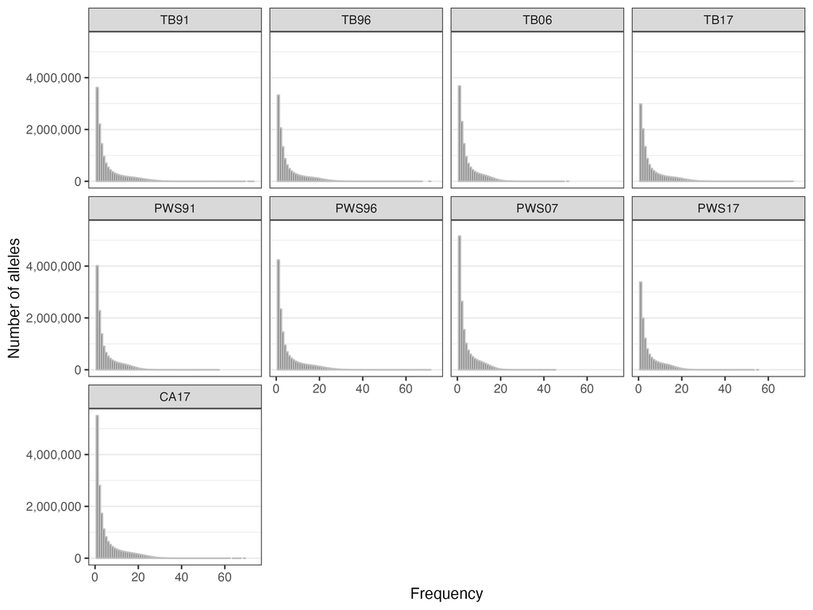

# 3 Compare Mafs.gz file from -doIBS run and -doSaf run for PWS17

- 1. -> angsd -bam /home/ktist/ph/data/angsd/samples/PWS17.txt -minMapQ 30 -minQ 20 -GL 2 -doMajorMinor 1 -doMaf 1 -SNP_pval 2e-6 -doIBS 1 -doCounts 1 -doCov 1 -makeMatrix 1 -minMaf 0 -P 24 -out /home/ktist/ph/data/angsd/single_read/PWS17  
     File size was 229.3Mb
- 2. -> angsd -bam /home/ktist/ph/data/angsd/samples/PWS17.txt -doSaf 1 -doMajorMinor 1 -GL 2 -doMaf 1 -doCounts 1 -doGlf 3 -doIBS 1 -SNP_pval 2e-6 -anc /home/jamcgirr/ph/data/c_harengus/c.harengus.fa -ref /home/jamcgirr/ph/data/c_harengus/c.harengus.fa -minMapQ 30 -minQ 20 -P 24 -uniqueOnly 1 -remove_bads 1 -only_proper_pairs 1 -trim 0 -C 50 -minInd 20 -setMaxDepth 1000 -out /home/ktist/ph/data/angsd/SFS/fromBam/PWS17_ibs

The main difference was having -uniqueOnly 1 -remove_bads 1 -only_proper_pairs 1

- -only_proper_pairs 1 Only use reads where the mate could be mapped – may be not appropriate for single-read???
- -remove_bads 1 Discard ‘bad’ reads, (flag & 512)
- -uniqueOnly 1 Discards reads that doesn’t map uniquely

```r
ibs1 <- fread('../Data/IBS/Done/PWS17.mafs.gz') #18,163,385 sites
#remove the sites that do not have 20 samples
ibs1<-ibs1[ibs1$nInd>=20, ] #15,133,767 sites (still doble of #2)

ibs2 <- fread('../Data/IBS/SFS/PWS17_ibs.mafs.gz') #7,089,349 sites


ch1.1<-ibs1[ibs1$chromo=="chr1",]
ch1.2<-ibs2[ibs2$chromo=="chr1",]

mean(ch1.1$knownEM) #0.1259165
mean(ch1.2$knownEM) #0.1235413

min(ch1.1$knownEM) #0.008929
min(ch1.2$knownEM) #0.00895


ch1.1$he<-2*ch1.1$knownEM*(1-ch1.1$knownEM)
mean(ch1.1$he, na.rm=T)#0.1889671
ch1.2$he<-2*ch1.2$knownEM*(1-ch1.2$knownEM)
mean(ch1.2$he, na.rm=T)
#0.1861933

# all numbers are highly similar in terms of mean MAF and Heterozygosity
# In order to calculate pi, we need the all sites SFS without using p-val cutoff
```

## 3.1 Pi (theta) from new file of PWS07 and PWS17

```r
#1. PWS07
pops2<-c("PWS07","PWS17")
full<-data.frame()
for (i in 1:length(pops2)){
    new_theta<-read.delim(paste0('../Data/IBS/',pops2[i],'_ibs_50kwin_10kstep.pestPG'))
    new_theta$pi<-new_theta$tP/new_theta$nSites
    new_theta<-new_theta[,c("Chr","WinCenter","pi","Tajima" )]
    new_theta$method<-"IBS"

    old_theta<-read.delim(paste0('../Data/new_vcf/angsd/fromBam/unfolded/',pops2[i],'_50kwin_10kstep.pestPG'))
    old_theta$pi<-old_theta$tP/old_theta$nSites
    old_theta<-old_theta[,c("Chr","WinCenter","pi","Tajima" )]
    old_theta$method<-"Full SAF"

    pi<-rbind(old_theta, new_theta)

    ggplot(pi, aes(x=method, y=pi))+
    geom_boxplot(color=cols[4], outlier.alpha = 0.5, outlier.size = 0.8)+
    geom_point(stat = "summary", fun = "mean")+
    ylab(expression(pi))+xlab("")+
    theme_bw()+ggtitle(pops2[i])+
    theme(panel.grid.major.x = element_blank())

    ggsave(paste0("../Output/SingleRead/Pi_estimates_compareIBS.vs.Full.",pops2[i],".png"), width = 3, height = 3, dpi=300)
}

#adding p-value cutoff for SNP calling will eliminate lower frequency or invariant sites so not appropriate for Theta estimates.
```

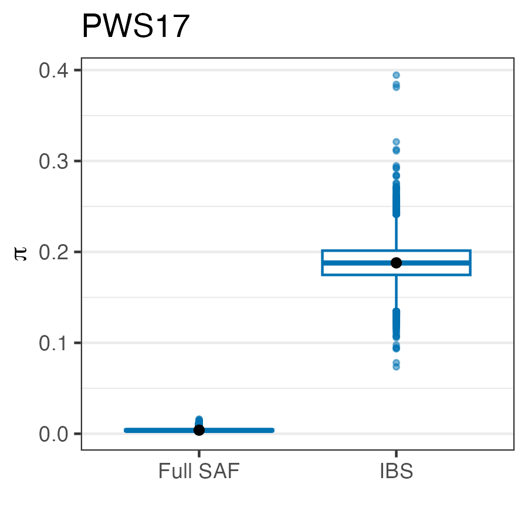

[figure not shown]

## 3.2 Pi (theta) estiamted from new IBS files

```r
#1. PWS07
pops2<-c("PWS91","PWS96","PWS07","PWS17")
full<-data.frame()
for (i in 1:length(pops2)){
    theta<-read.delim(paste0('../Data/IBS/',pops2[i],'_theta_ibs_50kwin_10kstep.pestPG'))
    theta$pi<-theta$tP/theta$nSites
    theta<-theta[,c("Chr","WinCenter","pi","Tajima" )]
    theta$pop<-pops2[i]
    full<-rbind(full, theta)
}

full$pop<-factor(full$pop, levels=pops2)

means <- aggregate(pi ~ pop,full, mean)
ggplot(full, aes(x=pop, y=pi, color=pop))+
        geom_boxplot(aes(color=pop), outlier.alpha = 0.2, outlier.size = 0.6)+
        theme_classic()+ ggtitle("PWS")+
        geom_point(stat = "summary", fun = "mean", color="gray40")+
         xlab("")+ylab(expression(pi))+
        geom_text(data = means, aes(label = round(pi, digits=5), y = pi + 0.015), color="gray40")
ggsave(paste0("../Output/Pi/Pi_pixy_mean.TB.png"), width = 4.5, height = 3, dpi=200)
```

[output not shown]

## 3.3 Tajima’s D.

```r
#Tajima's D (folded SFS)
theta<-data.frame()
for (i in 1:length(pops2)){
    theta2<-read.delim(paste0('../Data/IBS/',pops2[i],'_folded_theta_ibs_50kwin_10kstep.pestPG'))
    df<-theta2[,c("Chr","WinCenter","Tajima" )]
    df$pop<-pops2[i]
    theta<-rbind(theta, df)
}

theta$pop<-factor(theta$pop, levels=pops)
ggplot(theta, aes(x=pop, y=Tajima))+
    geom_boxplot(position=position_dodge(width = 0.8), color=org, outlier.alpha = 0.6,outlier.size = 0.7,width=0.6)+
    geom_point(stat = "summary", fun = "mean",position=position_dodge(width = 0.8))+
    ylab("Tajima's D")+xlab("")+
    theme_bw()+
    theme(panel.grid.major.x = element_blank())+
    geom_vline(xintercept = c(1.5,2.5,3.5), color="gray", size=0.5)
ggsave("../Output/SFS/TajimaD_PWS_fromBam.png", width = 5, height = 3.5)
```

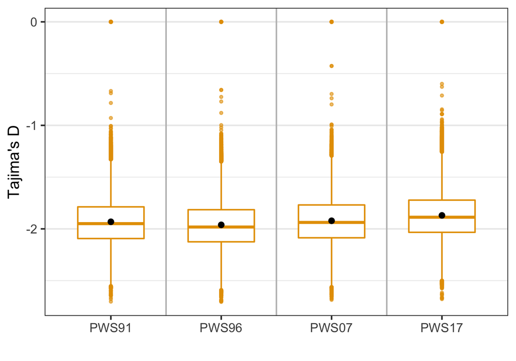

```r
sfiles<-list.files('../Output/SingleRead/', pattern="^Het_.+.csv.gz")

#calculate per site He

summaryHe<-data.frame(V=1:length(sfiles))
for (f in 1: length(sfiles)){
    af<-fread(paste0("../Output/SingleRead/", sfiles[f]))
    fname<-gsub("Het_",'',sfiles[f])
    fname<-gsub(".csv.gz",'', fname)

    af$het1<-af$knownEM*2*(1-af$knownEM)
    af$het2<-af$maf*2*(1-af$maf)

    write.csv(af, file=gzfile(paste0('../Output/SingleRead/',sfiles[f])))

    summaryHe$He_knownEM[f]<-mean(af$het1)
    summaryHe$He_maf[f]<-mean(af$het2, na.rm=T)
}


# set window size and window jump
window_size <- 50000
window_jump <- 10000
Chrsize<-read.delim("../Data/new_vcf/chr_sizes.bed", header = F)
names(Chrsize)<-c("chr","start","end")






for (f in 1: length(sfiles)){
    af<-fread(paste0("../Output/SingleRead/", sfiles[f]))
    fname<-gsub("MAF_",'',sfiles[f])
    fname<-gsub(".csv.gz",'', fname)
    He_windows<-data.frame()
    for (i in 1:26){
        # use seq to find the start points of each window
        window_start <- seq(from = 1, to = Chrsize$end[i], by = window_jump)
        # add the size of the window to each start point
        window_stop <- window_start + window_size-1

        window_start <- window_start[which(window_stop < Chrsize$end[i])]
        window_stop <- window_stop[which(window_stop < Chrsize$end[i])]

        # save as a data.frame
        windows <- data.frame(chr=paste0("chr",i),start = window_start, stop = window_stop,
                          mid = window_start + (window_stop-window_start)/2)


        df<-af[af$chromo==paste0("chr",i),]

        #window-based He per chromosome
        for (j in 1:nrow(windows)){
            dat<-df[df$position>=windows$start[j] & df$position<=windows$stop[j],]
            n=50000-nrow(dat)

            windows$het1[j]<-mean(c(dat$het1, rep(0, times=n)), na.rm=T)
            windows$het2[j]<-mean(c(dat$het2, rep(0, times=n)), na.rm=T)
        }

        He_windows<-rbind(He_windows, windows)

    }
    write.csv(He_windows, file=gzfile(paste0("../Output/SingleRead/Het_windowed_",fname,".csv.gz")))




for (i in 1:26){
    # use seq to find the start points of each window
    window_start <- seq(from = 1, to = Chrsize$end[i], by = window_jump)
    # add the size of the window to each start point
    window_stop <- window_start + window_size-1

    window_start <- window_start[which(window_stop < Chrsize$end[i])]
    window_stop <- window_stop[which(window_stop < Chrsize$end[i])]

    # save as a data.frame
    windows <- data.frame(chr=paste0("chr",i),start = window_start, stop = window_stop,
                      mid = window_start + (window_stop-window_start)/2)

    for ()
    df<-af3[af3$chromo==paste0("chr",i),]
    #He per chromosome
    for (j in 1:nrow(windows)){
        dat<-df[df$position>=windows$start[j] & df$position<=windows$stop[j],]
        n=50000-nrow(dat)

        windows$het1[j]<-mean(c(dat$het1, rep(0, times=n)), na.rm=T)
        windows$het2[j]<-mean(c(dat$het2, rep(0, times=n)), na.rm=T)
    }

    He_windows<-rbind(He_windows, windows)
}

## This expected heterozygosity is from the IBS data with maf >0.05. To obtain the average he, assumed all other sites were het=0 and calculated the average for 50000 base windows.

mean(He_windows$het1)
#0.004742556
mean(He_windows$het2)
#0.004360721

# stats from bcftools and calculating 2pq for PWS07 (He) was 0.01794937 (using hard called genotypes)
```

[output not shown]